# 06. 이질적 처치효과

- **처치가 사람마다 어떻게 다른 영향을 미치는지에 초점**
- 처치효과가 일정하지 않고, 어떤 대상이 처치에 더 잘 반응하는지 아는 것은 처치 대상을 결정하는 데 중요한 역할

  $\rightarrow$ **이질적 효과는 개인화라는 중요한 개념에 대해 인과추론으로 접근**

```python
import pandas as pd
import numpy as np
from matplotlib import pyplot as plt
import seaborn as sns

import matplotlib
import statsmodels.formula.api as smf
import warnings
warnings.filterwarnings("ignore")

from cycler import cycler

color=['0.0', '0.4', '0.8']
default_cycler = (cycler(color=color))
linestyle=['-', '--', ':', '-.']
marker=['o', 'v', 'd', 'p']

plt.rc('axes', prop_cycle=default_cycler)

matplotlib.rcParams.update({'font.size': 18})
```

## 06.01. ATE에서 CATE로

- 처치에 대한 인과효과를 추정할 때마다 대부분 평균 처치효과인 ATE를 계산

$$\tau = E[Y_1 - Y_0]$$

- 처치가 연속형이 경우
  - $y'$ : 처치 반응 함수의 도함수

$$\tau = E[y'(t)]$$

- **ATE는 전체 모집단단위에 대한 분석에 사용**

#### 누구에게 처치해야 하는가?

- 실험 대상에서 다른 대상으로 처치를 적용하는 결정이 바뀔 수 있도록해야 함
- 예) 어떤 고객에게 할인 쿠폰을 주면 유익하지만, 다른 고객에게는 그렇지 않을 수 있음
  - 고객마다 할인 민감도가 다를 수 있기 때문

  $\rightarrow$ 개인화의 역할

  $\rightarrow$ **개인화를 위한 한 가지 방법은 이질적 효과를 고려해서 조건부 평균 처치효과 (CATE)를 추정하는 것**
- 각 실험 대상의 고유한 특성을 고려함으로써 특정 사례에 가장 효과적인 처치를 결정할 수 있음

$$E[Y_1 - Y_0 |X] \text{또는} E[y'(t) |X]$$

- **$X$에 대한 조건부는 각 실험 대상이 공변량 $X$로 정의된 특성에 따라 처치효과가 다를 수 있음을 의미** $\rightarrow$ **모든 대상이 처치에 동일하게 반응하지 않는다는 가정**
- **이진 처치의 경우 알맞은 실험 대상에만 처치하고, 연속형 처치의 경우 각 대상이 맞는 최적의 처치 수준을 파악하는 것이 목표**
  - 예) 은행에서 각 고객에게 제공할 대출 금액을 결정할 떄, 모든 고객에게 큰 금액의 대출을 제공하는 것은 바람직하지 않음
    - 일부 고객에게는 큰 금액의 대출이 합리적이겠지만, 대출 금액 (처치)를 결정할 떄는 신중해야함

## 06.02. 예측이 답이 아닌 이유

### 고객 세분화 (Segmentation)

- 예) 할인에 잘 반응하는 고객과 할인에 잘 반응하지 않는 고객을 찾으려 하는 상황에서,

  고객의 처치에 대한 반응은 조건부 처치효과 $\frac{\delta Y}{\delta T}$로 구할 수 있음

  $\rightarrow$ **각 고객에 대해 이 값을 추정할 수 있다면, 처치에 잘 반응하는 고객 (높은 처치 효과)과, 잘 반응하지 않는 고객을 그룹으로 나눌 수 있음**

[figure not shown]

#### 기존 머신러닝 접근법의 비교

- **머신러닝은 각 실험 대상의 도함수 $\frac{\delta Y}{\delta T}$가 아닌, $Y$를 예측**

  $\rightarrow$ $y$축에 따라 공간을 분할하게 되며, 예측 모델이 목표를 잘 근사할 것이라고 가정

  $\rightarrow$ **그러나, 이 방법으로는 처치효과가 다른 그룹들을 찾을 수 없으며, 단순히 결과를 예측하는 것에 한정**

#### CATE와 ITE

- 조건부 평균 처치효과 (CATE)는 개별 처치효과 (ITE)와 다름
  - 예) $x=1$과 $x=2$는 두 그룹이 있고, 각 그룹에는 4명의 실험 대상이 존재할 때,
    - 일반적인 치사율이 50%인 질병에 걸린 환자에게 신약이 미치는 실험
    - $x=1$인 그룹에서 신약은 어떤 환자에는 해로워 사망에 이르게 하지만, 어떤 환자는 살림
    - $x=2$인 그룹에서 신약이 효과가 없으며 그 중 1명이 사망 (치사율 50%)

    $\rightarrow$ **두 그룹 모두 CATE는 0.5지만, 그 어떤 실험 대상의 ITE도 0.5는 아님**

## 06.03. CATE with Regression

> 전국적으로 운영되는 레스토랑 체인에서 중요한 점은 고객에게 할인을 제공해야 하는 **적절한 시기**를 파악하는 것

> 이 회사는 3년 동안 전국적으로 실험을 진행하여, 6개의 체인점에서 무작위로 할인을 제공

```python
data = pd.read_csv("./data/daily_restaurant_sales.csv")
data.head()
```

|  | rest_id | day | month | weekday | weekend | is_holiday | is_dec | is_nov | competitors_price | discounts | sales |
| --- | --- | --- | --- | --- | --- | --- | --- | --- | --- | --- | --- |
| 0 | 0 | 2016-01-01 | 1 | 4 | False | True | False | False | 2.88 | 0 | 79.0 |
| 1 | 0 | 2016-01-02 | 1 | 5 | True | False | False | False | 2.64 | 0 | 57.0 |
| 2 | 0 | 2016-01-03 | 1 | 6 | True | False | False | False | 2.08 | 5 | 294.0 |
| 3 | 0 | 2016-01-04 | 1 | 0 | False | False | False | False | 3.37 | 15 | 676.5 |
| 4 | 0 | 2016-01-05 | 1 | 1 | False | False | False | False | 3.79 | 0 | 66.0 |

- 분석의 목표는 할인을 제공하기 가장 좋은 시기를 파악하는 것이며,

  데이터에는 각 레스토랑의요일 조합에 관한 행이 하나씩 존재

  $\rightarrow$ **고객 대신 요일에 '처치'를 적용**
- **각 날짜와 공변량에 대한 할인의 매출 민감도를 나타내는 모델을 생성**
  - CATE의 추정은 $E[Sales(t) | X] = E[Sales|T = t, X]$

$$ \frac{\delta}{\delta t} E[Sales(t) |X] $$

- 데이터에 다음과 같은 선형모델을 적용할 때

$$ y_t = \beta_0 + \beta_1 t_i + \beta_2 X_i + e_i $$

**처치에 대해 미분하면 다음과 같은 결과이며, 처치가 무작위 배정되었다면 해당 회귀계수는 ATE**

$$ \frac{\delta y_i}{\delta t_i} = \beta_1 $$

- **모델을 추정하여 $\hat{\beta_1}$을 얻을 수 있으므로, 관측할 수 없는 기울기를 예측할 수 있지만 이는 CATE는 아님**

  **모든 실험 대상(일자와 레스토랑의 조합)의 기울이 예측값이 동일하므로, 언제 할인을 해야 하는지 파악하는데 도움이 되지 않음**

$\rightarrow$ **모델을 변화**

$$y_t = \beta_0 + \beta_1 t_i + \beta_2 X_i + \beta_3 t_i X_i + e_i$$

$\rightarrow$ **기울기 예측값은 $\beta_3$은 특성 $X$에 대한 벡터 계수**

$$ \frac{\hat{\delta y_i}}{\delta t_i} = \hat{\beta_1} + \hat{\beta_3}X_i $$

$\rightarrow$ **각기 다른 $X_i$로 정의된 개별 대상마다 기울기 예측값이 다름**

**즉, $X$가 변함에 따라 기울기 예측값도 변함**

$\rightarrow$ **직관적으로 처치와 공변량 간의 상호작용을 모델에 포함함으로써, 해당 공변량에 따라 효과가 어떻게 변하는지 모델이 학습할 수 있음**

$\rightarrow$ **비록 직접 예측할 수는 없지만 CATE를 추정하는 데 도움**

#### 데이터의 적용

- **공변량**
  - 날짜별 특성(월, 요일, 휴일 여부)
  - 각 레스토랑에서의 할인에 대한 고객 반응에 영향을 미칠 수 있는 경쟁업체의 평균 가격

$$ sales_i = \beta_0 + \beta_1 discount_i + \beta_2 X_i * discount_i + \beta_3 X_i + e_i $$

- **예측된 기울기**
  - $\beta_1$은 할인에 대한 계수
  - $\beta_3$은 상호작용 항에 대한 계수

$$ \frac{\hat{\delta sales_i}}{\delta discounts_i} = \hat{\beta_1} + \hat{\beta_3} X_i $$

```python
X = ["C(month)", "C(weekday)", "is_holiday", "competitors_price"]
print(f"sales ~ discounts*({'+'.join(X)})")

regr_cate = smf.ols(f"sales ~ discounts*({'+'.join(X)})", data=data).fit()
```

```
sales ~ discounts*(C(month)+C(weekday)+is_holiday+competitors_price)
```

#### 도함수 정의를 사용한 기울기 예측값

$$ \frac{\delta y}{\delta t} = \frac{y(t+\epsilon - y(t))}{(t+\epsilon)-t} $$

- $\epsilon$을 1로 대체하면, $\epsilon$이 0으로 수렴할 때의 근삿값 계산 가능

$$ \frac{\delta y}{\delta t} = \hat{y}(t+1) - \hat{y}(t) $$

$\rightarrow$ **원본 데이터를 그대로 사용한 예측값 $\hat{y}(t)$와, 원본 데이터를 사용하지만 처치를 한 단위씩 증가시킨 예측 $\hat{y}(t+1)$값의 차이가 CATE의 예측값**

```python
ols_cate_pred = (
    regr_cate.predict(data.assign(discounts=data["discounts"]+1)) - regr_cate.predict(data)
)
```

#### 가격 차별 예시 (Price Discrimination)

- **기업이 더 큰 비용을 지불할 의사가 있는 소비자와 그렇지 않은 소비자를 구별해 더 큰 비용을 청구하는 것**
  - 예) 항공사가 항공권을 언제 구입하는지에 따라 항공료를 다르게 책정하는 경우
  - 다음 주 항공편을 예약하는 고객은 내년 항공편을 예약하는 고객보다 더 큰비용을 지불할 것으로 예상

  $\rightarrow$ 시점간 가격 차별 (Intertemporal)은 회사가 시점에 따라 고객의 민감도를 구별할 수 있기 때문

## 06.04. CATE 예측 평가

- **CATE 예측은 일반 머신러닝 예측과 유사한 방법론을 사용하지만, 처치효과와 개인별 차이를 추정하는 것이 목표**

  **교차 검증과 같은 기존 머신러닝에서 사용하는 많은 모델 평가 방법을 적용할 수 있지만, 일부 방법은 약간의 조정이 필요**

  $\rightarrow$ 기초 방식처럼 데이터를 훈련 데이터셋과 테스트 셋으로 분할

  (훈련 셋으로는 2016년과 2017년의 데이터를, 테스트 셋으로는 2018년 이후의 데이터)

```python
train = data.query("day<'2018-01-01'")
test = data.query("day>='2018-01-01'")
```

- 테스트 셋에서는 예측을 수행

```python
X = ["C(month)", "C(weekday)", "is_holiday", "competitors_price"]
regr_model = smf.ols(f"sales ~ discounts*({'+'.join(X)})", data=train).fit()

cate_pred = (
    regr_model.predict(test.assign(discounts=test["discounts"]+1)) - regr_model.predict(test)
)
```

- 머신러닝 모델과 비교 : `ml_pred`

```python
from sklearn.ensemble import GradientBoostingRegressor
```

```python
X = ["month", "weekday", "is_holiday", "competitors_price", "discounts"]
y = "sales"

np.random.seed(1)
ml_model = GradientBoostingRegressor(n_estimators=50).fit(train[X], train[y])

ml_pred = ml_model.predict(test[X])
```

- -1과 1 사이의 난수와도 비교 : `rand_m_pred`

```python
np.random.seed(123)

test_pred = test.assign(
    ml_pred=ml_pred,
    cate_pred=cate_pred,
    rand_m_pred=np.random.uniform(-1, 1, len(test)),
)
```

```python
test_pred[["rest_id", "day", "sales", "ml_pred", "cate_pred", "rand_m_pred"]].head()
```

|  | rest_id | day | sales | ml_pred | cate_pred | rand_m_pred |
| --- | --- | --- | --- | --- | --- | --- |
| 731 | 0 | 2018-01-01 | 251.5 | 236.312960 | 41.355802 | 0.392938 |
| 732 | 0 | 2018-01-02 | 541.0 | 470.218050 | 44.743887 | -0.427721 |
| 733 | 0 | 2018-01-03 | 431.0 | 429.180652 | 39.783798 | -0.546297 |
| 734 | 0 | 2018-01-04 | 760.0 | 769.159322 | 40.770278 | 0.102630 |
| 735 | 0 | 2018-01-05 | 78.0 | 83.426070 | 40.666949 | 0.438938 |

## 06.05. 모델 분위수에 따른 효과

- CATE 모델은 어떤 대상이 처치에 더 민감한지를 찾아 처치를 더 효율적으로 배정하려는 필요성, 즉 개인화에 대한 필요성

  **실험 대상을 민감도가 높은 순서부터 낮은 순서로 나열하는 것은 개인화를 사용하는 데 용이**
- 처치가 무작위로 배정되었다면, 실험군과 대조군의 결과를 비교 가능하며, 그룹에 대한 효과를 추정하기 용이

  또는 그룹 내에서 $T$에 대한 $Y$의 단순회귀분석을 사용 가능
  - $\bar{t}$ : 처치에 대한 그룹 표본평균
  - $\bar{y}$ : 결과에 대한 그룹 표본평균

$$ y_t = \beta_0 + \beta_1 t_i + e_i | X = x $$$$ \hat{\beta_1} = \frac{\sum(t_i - \bar{t})y_i}{\sum (t_i - \bar{t})^2} $$

```python
from toolz import curry
```

```python
@curry
def effect(data, y, t):

        return (np.sum((data[t] - data[t].mean())*data[y]) / np.sum((data[t] - data[t].mean())**2))
```

- 단순 선형회귀 기울기 매개변수 추정값

```python
effect(test, "sales", "discounts")

# simple_regr = smf.ols("sales ~ discounts", data=train).fit()
# simple_regr.params
```

```
32.16196368039615
```

- 적합된 모델이 데이터를 세분화하여 처치에 더 민감한 대상과 덜 민감한 대상을 구분할 수 있는지 확인

  $\rightarrow$ **모델의 예측값에 따라 데이터를 분위수별로 세분화하고 각 분위수에서 효과를 추정할 수 있음**

  $\rightarrow$ 각 분위수에서 추정된 효과가 순서대로 정렬되었다면, 해당 모델이 실제 CATE를 잘 정렬하는 데도 효과적임을 알 수 있음

#### 반응 곡선 형태

- 효과를 $Y$를 $T$에 회귀한 결과의 기울기 추정값
  - 예) 반응 함수가 오목한 형태라고 생각한다면, 효과를 $log(T)$나 $\sqrt{T}$에 대한 $Y$의 회귀 기울기로 정의 가능
- 이진 결과의 경우, 선형회귀분석이 아닌 로지스틱 호귀의 매개변수 추정값을 사용하는 것이 적절

### 예측값의 분위수별 효과

1. **데이터를 예측값에 따라 `q`개의 분위수로 나누고, 각 그룹의 중간값을 추출**
2. **데이터 분위수 그룹에 대한 열을 만든 후, 데이터를 그룹별로 분할**
3. **각 그룹의 효과를 추정**

```python
def effect_by_quantile(df, pred, y, t, q=10):

    # 분위수에 대한 파티션
    groups = np.round(pd.IntervalIndex(pd.qcut(df[pred], q=q)).mid, 2)

    return (df
            .assign(**{f"{pred}_quantile": groups})
            .groupby(f"{pred}_quantile")
            # 각 분위수 그룹별 효과 추정
            .apply(effect(y=y, t=t)))
```

- **난수 모델 (`rand_m_pred`)**
  - 각 그룹의 추정된 효과가 거의 비슷함 $\rightarrow$ 할인에 민감한 날과 그렇지 않은 날을 구분하지 못함

  $\rightarrow$ 개인화에 도움이 되지 않음 $\rightarrow$ 모든 그룹의 효과는 ATE에 불과함
- **머신러닝 모델 (`ml_pred`)**
  - 예측값이 높거나 낮은 그룹 모두 할인에 더 민감
  - 정확한 순서를 정렬하지 않지만, 예측값이 매우 높거나 매우 낮을 때 더 많은 할인을 제공하는 방식으로 개인화에 활용
- **회귀 모델 (`cate_pred`)**
  - CATE가 낮게 예측된 그룹은 높게 예측된 그룹보다 실제로 CATE가 더 낮음

  $\rightarrow$ 분위수별 효과 그래프의 계단 모양을 통해, 높은 효과와 낮은 효과를 잘 구분하는 것으로 판단 가능

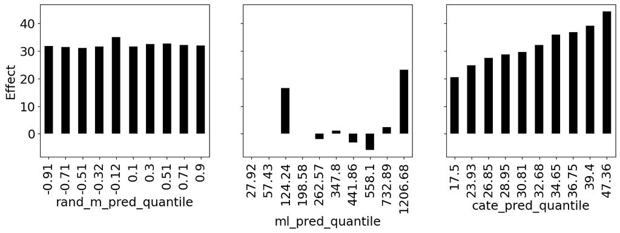

```python
fig, axs = plt.subplots(1, 3, sharey=True, figsize=(15, 4))
for m, ax in zip(["rand_m_pred", "ml_pred", "cate_pred"], axs):
    effect_by_quantile(test_pred, m, "sales", "discounts").plot.bar(ax=ax)
    ax.set_ylabel("Effect")

plt.show()
```

- 처치에 대한 민감도를 순서대로 나열하는 측면에서, 두 개의 괜찮은 모델이 있다면 명확하게 비교하는 것이 어려움

  $\rightarrow$ **시각적인 검증은 모델 선택 (하이퍼파라미터 튜닝, 특성 선택)에 있어서 이상적인 방법은 아님**

  $\rightarrow$ 누적 효과 곡선 필요

## 06.06. 누적 효과 곡선

- 상위 $n \%$까지 데이터를 누적했을 때, 그 집단의 평균적인 처치 효과
- 단위 : $y$의 단위
1. 데이터를 점수 순으로 정렬
- 보통 점수는 (민감도, CATE)
2. 해당 정렬에 따라 상위 1%의 효과를 추정
3. 1%를 추가하여 상위 2%의 효과를 계산
4. 반복
5. 누적 표본에 따른 효과 곡선 생성
- **데이터를 정렬하는 데 사용한 점수가 실제 CATE의 순서를 잘 반영했다면, 해당 곡선은 매우 높게 시작해서 점차 ATE에 수렴**

  **반면, 잘못된 모델은 ATE로 빠르게 수렴하거나 지속해서 그 주변에서 변동**

```python
np.set_printoptions(linewidth=80, threshold=10)
```

```python
def cumulative_effect_curve(dataset, prediction, y, t, ascending=False, steps=100):
    size = len(dataset)
    ordered_df = (dataset
                  .sort_values(prediction, ascending=ascending)
                  .reset_index(drop=True))

    steps = np.linspace(size/steps, size, steps).round(0)

    return np.array([effect(ordered_df.query(f"index<={row}"), t=t, y=y) for row in steps])
```

- 회귀 CATE 모델 (`cate_pred`)은 매우 높게 시작하여 점차 ATE로 수렴
  - 상위 20%의 ATE는 약 42, 상위 50%의 ATE는 약 37, 상위 100%의 ATE는 단순히 전체 처치효과인 ATE
- 난수 모델 (`rand_m_pred`)은 ATE 주변에서 변동

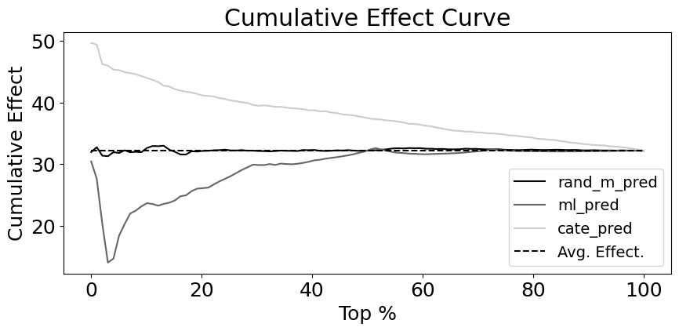

```python
plt.figure(figsize=(10,4))

for m in ["rand_m_pred", "ml_pred", "cate_pred"]:
    cumu_effect = cumulative_effect_curve(test_pred, m, "sales", "discounts", steps=100)
    x = np.array(range(len(cumu_effect)))
    plt.plot(100*(x/x.max()), cumu_effect, label=m)

plt.hlines(effect(test_pred, "sales", "discounts"), 0, 100, linestyles="--", color="black", label="Avg. Effect.")
plt.xlabel("Top %")
plt.ylabel("Cumulative Effect")
plt.title("Cumulative Effect Curve")
plt.legend(fontsize=14)
plt.show()
```

- 누적 효과 곡선은 단일 숫자로 효과를 요약 가능
  - 예) 곡선과 ATE사이의 면적을 계산하여 서로 다른 모델을 비교 가능

  $\rightarrow$ 면적이 클수록 좋은 모델임을 의미
- **하지만, 곡선의 시작 부분이 가장 큰 면적을 차지하면서, 표본 크기가 상대적으로 작기 때문에 불확실성이 가장 높음**

  $\rightarrow$ 누적 이득 곡선 (Cumulative Gain Curve)

## 06.07. 누적 이득 곡선

- **정의 : 무작위로 처치했을 때보다, 모델을 써서 상위 $x\%$를 선택했을 때, 추가로 얻는 총 이득**
  - **정규화 (`normalizer`) : 전체 데이터의 평균 효과 (ATE)를 차감 $\rightarrow$ 즉, 모델 덕분에 얻은 추가분만 계산**
  - **누적 표본 비중 (`row/size`) : $N_{cum} / N$을 각 데이터 포인트에 곱함**
- **모델의 성능은 정규화된 누적 이득 곡선의 합이며, 가장 큰 모델이 CATE 순서 측면에서 가장 좋은 모델**

  (**누적 이득 곡선의 중심이 위로 솟아오른 모형일수록 좋은 모델**)

```python
def cumulative_gain_curve(df, prediction, y, t, ascending=False, normalize=False, steps=100):

    effect_fn = effect(t=t, y=y)
    normalizer = effect_fn(df) if normalize else 0

    size = len(df)
    ordered_df = (df
                  .sort_values(prediction, ascending=ascending)
                  .reset_index(drop=True))

    steps = np.linspace(size/steps, size, steps).round(0)
    effects = [(effect_fn(ordered_df.query(f"index<={row}")) -normalizer)*(row/size) for row in steps]

    return np.array([0] + effects)
```

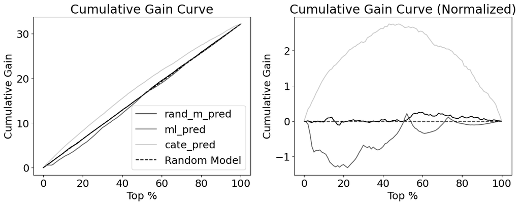

```python
fig, (ax1, ax2) = plt.subplots(1, 2, figsize=(15,5))

for m in ["rand_m_pred", "ml_pred", "cate_pred"]:
    cumu_gain = cumulative_gain_curve(test_pred, m, "sales", "discounts")
    x = np.array(range(len(cumu_gain)))
    ax1.plot(100*(x/x.max()), cumu_gain, label=m)

ax1.plot([0, 100], [0, effect(test_pred, "sales", "discounts")], linestyle="--", label="Random Model", color="black")

ax1.set_xlabel("Top %")
ax1.set_ylabel("Cumulative Gain")
ax1.set_title("Cumulative Gain Curve")
ax1.legend()


for m in ["rand_m_pred", "ml_pred", "cate_pred"]:
    cumu_gain = cumulative_gain_curve(test_pred, m, "sales", "discounts", normalize=True)
    x = np.array(range(len(cumu_gain)))
    ax2.plot(100*(x/x.max()), cumu_gain, label=m)

ax2.hlines(0, 0, 100, linestyle="--", label="Random Model", color="black")

ax2.set_xlabel("Top %")
ax2.set_ylabel("Cumulative Gain")
ax2.set_title("Cumulative Gain Curve (Normalized)")

plt.show()
```

- 각 모델의 AUC

```python
for m in ["rand_m_pred", "ml_pred", "cate_pred"]:
    gain = cumulative_gain_curve(test_pred, m, "sales", "discounts", normalize=True)
    print(f"AUC for {m}:", sum(gain))
```

```
AUC for rand_m_pred: 6.0745233598544495
AUC for ml_pred: -45.44063124684
AUC for cate_pred: 181.7407448835955
```

### 모델의 성능의 표현

- **모델의 성능을 단일 숫자로 표현하면 모델 선택을 자동화하는 데 유용**
1. **곡선은 CATE를 정확히 추정하는 것이 아닌, 순서가 올바른지에 관심**
- 예) 모델의 예측값에서 -1,000을 빼더라도 누적 이득 곡선은 변하지 않음

  $\rightarrow$ **CATE에 대해 편향된 추정량이 있더라도, 이 곡선에는 나타나지 않음**
2. **모든 곡선에서 각 곡선 위의 점은 추정값이며, 참 값이 아님**
- 이는 특정 그룹 (때로는 매우 작은 그룹)에 대한 회귀계수의 추정값
- **회귀계수 추정값은 $T$와 $Y$의 관계가 올바르게 정해졌는지에 따라 달라짐**
  - 무작위 배정이 되었다고 해도, 처치와 결과 사이의 관계가 로그 함수일 때 선형으로 추정하면 잘못된 결과가 나올 수 있음
3. **교란이 없는 데이터가 필요**
- 편향이 있으면 추정하는 효과(하위 그룹이나 ATE)가 잘못될 수 있음
- 처치가 무작위 배정되지 않은 경우에도, IPW의 직교화 등을 사용하여 데이터 편향을 제거한 후 곡선 기법을 적용 가능

  (하지만, 적어도 평가 목적을 위해서라도 실험 데이터가 유용)

## 06.08. 목표 변환 (Target Transformation)

- **실제 처치효과 $\tau(x_i)$를 관측할 수는 없지만, 기댓값에서 실제 처치효과를 근사하는 목표 변수**
  - $\mu_y$는 결과에 대한 모델
  - $\mu_t$는 처치에 대한 모델
- **분자 : $Y$의 잔차**
- **분모 : $T$의 잔차**

  $\rightarrow$ **"예상치 못한 처치에 따라 발생한, 예상치 못한 값의 변동"**

  $\rightarrow$ **즉, 다른 요인 ($X$)로 설명되지 않는 순수한 변화의 비율이며, 개별 수준의 기울기(효과)**

  (분자는 $Y$와 $T$사이의 공분산이고, 분모가 $T$의 분산이라는 점에서 회귀계수의 공식과 매우 비슷하지만, 기댓값을 사용하는 대신 실험 대상 수준에서 계산됨)

$$ Y^*_{i} = \frac{(Y_i - \hat{\mu_y}(X_i))(T_i - \hat{\mu_t}(X_i))}{(T_i - \hat{\mu_t}(T_i))^2} = \frac{Y_i- \hat{\mu_y}(X_i)}{T_i -\hat{\mu_t}(X_i)} $$

- **예상치 못한 처치가 1단위 변했을 때, 결과갑이 얼마나 변했는가? 라는 개별 데이터 포인트 $(i)$에서의 기울기를 구하는 것**
- 일반적인 회귀분석이 집단 전체의 평균 기울기를 변한다면, 이 방식은 각 개인 수준에서 그 효과를 추정하려고 시도

$$ E[Y^*_{i}] = \tau_i $$

- 목표 변수는 실제 처치효과를 근사하므로, MSE와 같은 지표를 계산하는 데 사용 가능
  - CATE에 대한 모델이 개별 수준 효과 $\tau_i$를 예측하는 데 효과적이라면, 목표변수에 대한 모델의 에측 MSE는 작아야 함
- **목표변수는 처치의 평균값에 가까워지면 분모가 0에 가까워지는 경향**

  $\rightarrow$ **잡음이 매우 증가**

  $\rightarrow$ **$T_i - \hat{\mu_i}(X_i)$가 작은 지점에 낮은 중요도를 부여하는 가중치를 적용**

  (예: 실험 대상에 $(T_i - \hat{\mu} (X_i))^2$로 가중치 적용)
- 결과의 잔차를 처치 모델의 잔차로 나눈 $\hat{\tau}$

```python
X = ["C(month)", "C(weekday)", "is_holiday", "competitors_price"]

y_res = smf.ols(f"sales ~ {'+'.join(X)}", data=test).fit().resid
t_res = smf.ols(f"discounts ~ {'+'.join(X)}", data=test).fit().resid

tau_hat = y_res/t_res
```

- 이를 사용하여 모든 모델의 MSE 계산 (가중치 $(T_i - \hat{\mu} (X_i))^2$ 적용)
  - CATE를 추정하는 데 사용한 회귀 모델이 다른 두 모델보다 성능이 더 좋음
  - 머신러닝 모델이 난수모델보다 성능이 더 나쁨 $\rightarrow$ 머신러닝 모델은 $\tau_i$가 아닌 $Y$를 예측하려고 하기 때문

```python
from sklearn.metrics import mean_squared_error
```

```python
for m in ["rand_m_pred", "ml_pred", "cate_pred"]:
    wmse = mean_squared_error(tau_hat, test_pred[m], sample_weight=t_res**2)
    print(f"MSE for {m}:", wmse)
```

```
MSE for rand_m_pred: 1115.803515760459
MSE for ml_pred: 576256.7425385391
MSE for cate_pred: 42.90447405550269
```

- **결과가 효과와 상관관계가 있을 때만, $Y$를 예측하는 것이 처치효과의 순서 정렬이나 개별 수준 효과 $\tau_i$를 예측하는 데 효과적**

  $\rightarrow$ **머신러닝과 인과추론의 결정적인 차이**

  $\rightarrow$ 단순히 $Y$를 잘 맞추는 모델이, '처치를 했을 때의 변화량 $\tau$'를 잘 맞추는 모델은 아닐 수도 있음
  - $Y$ 예측 vs $\tau$ 예측의 차이
    - $Y$ 예측 : '이 고개의 내일 매출은 얼마인가?'
    - $\tau$예측 : '이 고객에게 쿠폰을 줬을 때, 안 줬을 때보다 매출이 얼마나 더 오르는가?'

  $\rightarrow$ **'원래 많이 구매를 하는 고객이, 처치(쿠폰)에 대한 반응도 좋다'라는 가정이 성립할 때만**, $Y$ 예측 모델이 $\tau$예측 모델의 역할을 대신할 수 있음

## 06.03. 예측모델이 효과 정렬에 좋을 때

- $Y$를 예측하는 것은 효과가 결과와 상관관계가 있을 때만 순서를 잘 나타내거나 $\tau_i$를 잘 예측하는 데 유용
  - 예) 레스토랑에서 고객이 할인에 더 민감하게 반응하는 날
    - 매출이 높은 날에 사람들이 할인에 더 민감하게 반응한다면, $Y$를 예측하는 모델은 $T$가 $Y$에 미치는 효과의 순서도 잘 예측

    $\rightarrow$ 일반적으로 처치 반응 함수가 비선형일 때 발생

### 01. 한계 수확 체감 (Marginal Decreasing Returns)

- 처치 반응 함수가 오목하면 처치 단위가 늘어날수록 효과가 점점 줄어들게 됨

  $\rightarrow$ **대부분의 경우 포화점 (Saturation Point)가 존재함**
  - 예) 할인율을 100%로 설정하더라도 판매량은 높아지는 데 한계가 존재
- 예) 한계적으로 (Marginally) 감소하는 처치 반응 함수

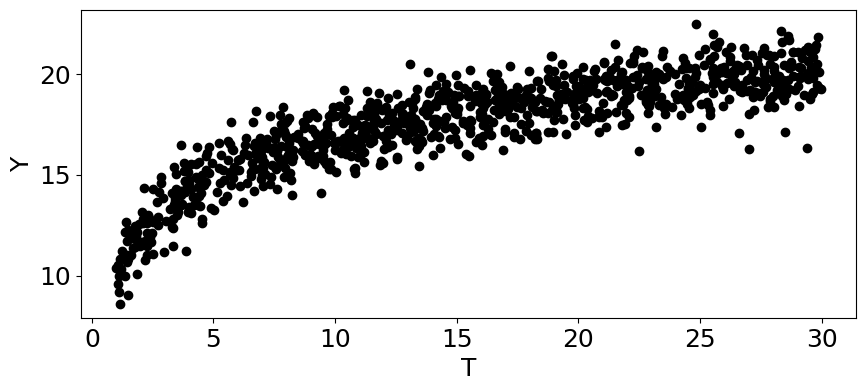

```python
np.random.seed(123)

n = 1000
t = np.random.uniform(1, 30, size=n)
y = np.random.normal(10+3*np.log(t), size=n)

plt.figure(figsize=(10,4))
plt.scatter(t, y)
plt.ylabel("Y")
plt.xlabel("T")

plt.show()
```

### 이진 결과

- **결과 $Y$가 이진값일 때 $Y$를 예측하는 모델이 CATE를 잘 정렬하는 데 유용**
  - $E[T|T]$는 0과 11 사이에서 평평해지는 S자 모양

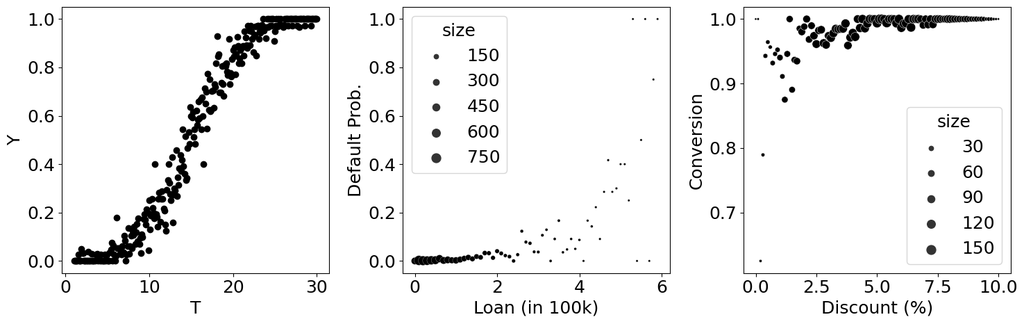

```python
np.random.seed(123)

fig, (ax1, ax2, ax3) = plt.subplots(1, 3, figsize=(15, 5))

n = 10000
t = np.random.uniform(1, 30, size=n).round(1)
y = (np.random.normal(t, 5, size=n) > 15).astype(int)

df_sim = pd.DataFrame(dict(t=t, y=y)).groupby("t")["y"].mean().reset_index()
df_sim

ax1.scatter(df_sim["t"], df_sim["y"])
ax1.set_ylabel("Y")
ax1.set_xlabel("T")


n = 10000
t = np.random.exponential(1, n).round(1).clip(0, 8)
y = (np.random.normal(t, 2, size=n) > 6).astype(int)

df_sim = (pd.DataFrame(dict(t=t, y=y, size=1))
          .query("t<6")
          .groupby("t")
          .agg({"y":"mean", "size":"sum"})
          .reset_index())

sns.scatterplot(data=df_sim, y="y", x="t", size="size", ax=ax2, sizes=(5,100))
ax2.set_ylabel("Default Prob.")
ax2.set_xlabel("Loan (in 100k)")


n = 10000
t = np.random.beta(2, 2, n).round(2)*10
y = (np.random.normal(5+t, 4, size=n) > 0).astype(int)

df_sim = (pd.DataFrame(dict(t=t, y=y, size=1))
          .groupby("t")
          .agg({"y":"mean", "size":"sum"})
          .reset_index())

sns.scatterplot(data=df_sim, y="y", x="t", size="size", ax=ax3, sizes=(5,100))
ax3.set_ylabel("Conversion")
ax3.set_xlabel("Discount (%)")
plt.tight_layout()
plt.show()
```

- 대부분의 비즈니스 적용 사례에서 데이터는 S자형 함수의 한쪽이나 다른 쪽 끝에 집중
  - 예) 금융업계에서는 대출 상환이 채무불이행되는 고객 비율이 극히 낮기 때문에, 부도율 ($Y=1$)이 매우 낮음 $\rightarrow$ 이 곡선의 왼쪽 부분에 위치하게 되며, 이 부분은 지수함수의 형태

    $\rightarrow$ 결과적으로 고객의 대출 채무불이행을 예측하는 모델이 있다면, 예측값이 높은 고객일수록 처치에 더 민감하게 반응할 가능성이 높음

    $\rightarrow$ 이 고객들은 대출 채무불이행과 상환 사이의 분기점에 가까운 고객이며, 처치의 작은 변화가 결정적인 차이를 만들 수 있음
  - 예) 온라인 쇼핑몰 웹사이트를 방문하는 대부분의 고객이 구매(전환)한다고 가정할 때, 반대로 이 경우 S곡선의 오른쪽에 해당

    $\rightarrow$ 구매 전환을 예측하는 모델이 있다면, 이 모델이 할인과 같은 처치효과도 순서대로 정렬하는 데 유용

    $\rightarrow$ 전환 가능성이 높을수록 효과 크기는 작아짐

    $\rightarrow$ 이는 S곡선 우측부분이 수익이 점진적으로 감소나는 경우(한계 수확 체감)와 비슷하기 때문
- **일반적으로 이진 결과의 경우, 중간값에 가까울수록 ($E[Y|T]=50\%$) 효과가 증가 (S커브의 기울기가 가장 가파름)**

  $\rightarrow$ **즉, 결과가 불확실한 집단일수록 작은 처치에도 결과과 뒤바뀔 가능성이 가장 큼**
- 처치 반응 함수가 이진 결과처럼 비선형적이거나 결과가 한계(점진)적으로 감소하는 경우, 예측 모델은 CATE의 순서를 잘 정렬할 수 있음
- 하지만 이것이 가장 좋은 모델임을 의미하지는 않으며, ㅊATE를 직접 예측하는 목적으로 개발한 모델보다 성능이 좋다는 의미도 아님
- 이러한 모델은 처치효과의 순서를 잘 정렬할 수는 있지만, 처치효과를 예츠하지는 않음

  $\rightarrow$ 처치에 대한 민감도에 따라 대상을 정렬하는 데 중요한 경우에만 적합

  $\rightarrow$ 결정을 내리는 데 있어서 CATE를 정확히 추정하는 것이 중요하다면, 그룹별 효과 추정이 필요

## 06-10. 의사결정을 위한 CATE

- 이진 처치일 때 의사결정 과정은 매우 간단함 $\rightarrow$ 누가 처치에 가장 긍정적으로 반응하는가?
- 처치를 무한정으로 줄 수 있다면, CATE가 양수인 모든 사람들에게 처치
- **만약 CATE를 예측하는 모델이 없지만, 순서를 정할 수 있는 모델이 있따면, 모델 분위수에 따른 효과 그래프를 사용할 수 있음**

  **모델의 분위수별로 데이터를 나누고, 각 분위수에서 처치효과를 추정한 다음, 효과가 여전히 양의 값을 보이는 지점까지 모든 대상에게 처치**
- **처치를 무한정으로 줄 수 없다면, 추가 규칙 설정이 필요**
  - 단순히 긍정적인 효과가 있는 대상뿐만 아니라, CATE가 가장 높은 대상에도 처치해야함
  - **예) 처치 대상이 1,000명으로 제한된다면, CATE순서에 따라 상위 1,000명을 선택하되, 모두 긍정적인 효과가 있는 경우에만 처치하는 것이 바람직**
- **처치가 연속형이거나 정렬된 경우**
  - 누구에게 처치를 할지 뿐만 아니라, 어느 정도의 처치를 줄지도 결정해야 함

  $\rightarrow$ 사업의 특성에 따라 매우다를 수 있으며, 각 문제에는 최적화해야 할 고유한 처치 반응 함수가 존재

#### 레스토랑 체인에서 매일 얼마나 할인을 제공할지 결정하는 문제

- 얼마나 할인을 제공할지 결정하는 일은 어떤 가격을 책정할지 결정하는 것 ($\text{Price} = \text{Price}_{base} \times (1- \text{Discount})$)

  $\rightarrow$ 최적화 문제로의 재정의: 모든 비즈니스 문제에는 비용과 수익 함수가 존재

$$ Demand_i = 50 - \tau (X_i) Price_i $$$$ Revenue_i = Demand_i \times Price_i $$

- **특정 날자 $i$의 매출은 레스토랑에서 제공하는 식사 수(수요)에 가격을 곱한 값**
  - 그러나 특정 날짜에 사람들이 구매하려는 식사 수는 해당 날짜에 부과되는 가격에 반비례

  $\rightarrow$ $\tau(X_i)$는 해당 날짜에 고객이 가격 인상에 얼마나 민감한지를 나타냄 $\rightarrow$ 이 민감도는 가격이 수요에 미치는 CATE
- $\tau$의 다양한 값에 대한 수요 곡선을 그려보면, $\tau$가 수요 곡선의 기울기임을 알 수 있음
- 수요 곡선에 수익 곡선을 곱하면, 이차 곡선의 형태가 나타나며, 고객들이 가격에 대해 덜 민감해지는날 $\tau = 1$은 더 높은 가격에서 정점

```python
def demand(price, tau):
    return 50-tau*price
```

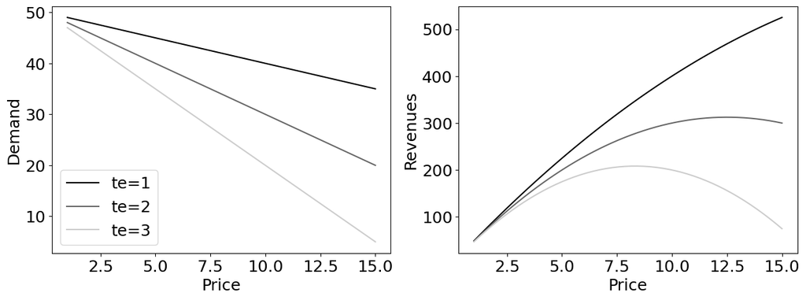

```python
fig, (ax1, ax2) = plt.subplots(1, 2, figsize=(15, 5))

prices = np.linspace(1, 15)

for i, tau in enumerate([1, 2, 3]):
    q = demand(prices, tau)
    ax1.plot(prices, q, color=f"C{i}", label=f"te={tau}")
    ax2.plot(prices, q*prices, color=f"C{i}", label=f"te={tau}")

ax1.set_ylabel("Demand")
ax1.set_xlabel("Price")

ax2.set_ylabel("Revenues")
ax2.set_xlabel("Price")

ax1.legend()
plt.show()
```

- 식사를 만드는 데 3달러가 든다고 가정 $\rightarrow$ 비용은 단순히 생산량인 $q$에 3을 곱한 값

$$ Costs(q_i) = 3q_i $$

```python
def cost(q):
    return q*3
```

- 비용 방정식은 처치효과에 직접 의존하지는 않지만, 생산량은 고객 주문량(즉, 수요)이기에, 가격이 높을수록 고객의 식사 수요가 줄어들기 때문에 비용이 낮아짐
- 수익과 비용을 모두 얻게 되면,이를결합하여 가격의 함수로 이익을 계산

$$Profit_i = Demand_i \times Price_i - Cost(Demand_i)$$

```python
def profit(price, tau):
    q = demand(price, tau)
    return q*price - cost(q)
```

- 다른 $\tau_i$값에 대한 가격별 이익을 시각화하면, 각기 다른 최적 가격이 산출됨을 알 수 있음
  - $\tau_i$가 낮을수록 가격 인상에 덜 민감해지며, 이는 레스토랑이 가격을 올려 더 많은 이익을 낼 수 있게함

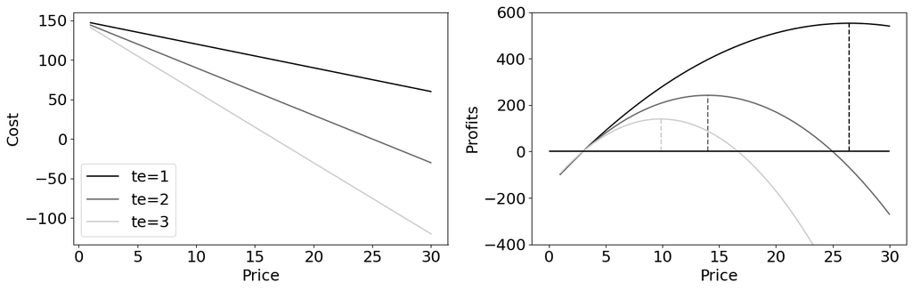

```python
prices = np.linspace(1, 30)

fig, (ax1, ax2) = plt.subplots(1, 2, figsize=(15, 5))

for i, tau in enumerate([1, 2, 3]):
    profits = profit(prices, tau)

    max_price = prices[np.argmax(profits)]

    ax1.plot(prices, cost(demand(prices, tau)), label=f"te={tau}")

    ax2.plot(prices, profits, color=f"C{i}", label=f"te={tau}")
    ax2.vlines(max_price, 0, max(profits), color=f"C{i}", linestyle="--")
    ax2.set_ylim(-400, 600)


ax2.hlines(0, 0, max(prices), color="black")
# ax2.legend()
ax2.set_ylabel("Profits")
ax2.set_xlabel("Price");

ax1.legend()
ax1.set_ylabel("Cost")
ax1.set_xlabel("Price")

plt.tight_layout()
plt.show()
```

- **CATE 예측은 수익 및 비용 곡선의 형태에 따라 크게 달라지며, 비즈니스에 따라 크게 달라짐**

  **하지만 일반적으로 최적화하려는 거의 모든 처치에는 상승하는 값(수익)과 하락하는 값(비용)이 존재하며,**

  **연속형 처치의 수준을 결정할 때 CATE를 사용하려면 이 두 가지 측면에 어떤 영향을 미치는지 이해하고 있어야 함**